# Project-Final

Nihal Biswas

2023-06-10

# Exporting Data

```r
library(readxl)
setwd("C:\\Users\\Admin\\Desktop\\college\\project")
electric=read_excel("Compiled.xlsx",sheet = "Sheet2")
electric=electric[,-2:-3]
electric_only=na.omit(electric[,1:5])
head(electric)
```

```
## # A tibble: 6 × 6
##    YEAR Electric_power_consumption_(kW…¹ Urban_Population %_of_Urban_populatio…²
##   <dbl>                            <dbl>            <dbl>                  <dbl>
## 1  1960                               NA         79932899                   17.9
## 2  1961                               NA         82289370                   18.0
## 3  1962                               NA         85082467                   18.2
## 4  1963                               NA         87963683                   18.4
## 5  1964                               NA         90940579                   18.6
## 6  1965                               NA         93946480                   18.8
## # ℹ abbreviated names: ¹`Electric_power_consumption_(kWh_per_capita)`,
## #   ²`%_of_Urban_population_from_total_population`
## # ℹ 2 more variables: `Annual_%_Change_in_population` <dbl>,
## #   `Total Industries` <dbl>
```

# FORECASTING URBAN POPULATION TILL 2050

```r
library(tseries)
library(forecast)
library(urca)
adf.test(electric$Urban_Population)
```

```
##
##  Augmented Dickey-Fuller Test
##
## data:  electric$Urban_Population
## Dickey-Fuller = -0.96787, Lag order = 3, p-value = 0.9357
## alternative hypothesis: stationary
```

- P value greater than 0.05, hence the data is not stationary.
- We thus the ACF value to see the optimum number of lags at which the data becomes stationary.

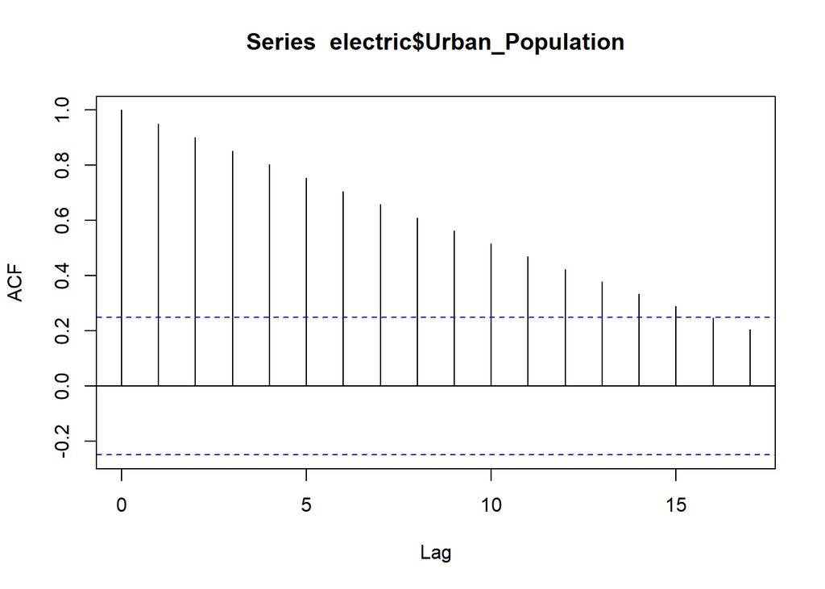

```r
acf(electric$Urban_Population)
```

```r
Urbanpop_lag = diff(electric$Urban_Population,lag = 15)
adf.test(Urbanpop_lag)
```

```
##
##  Augmented Dickey-Fuller Test
##
## data:  Urbanpop_lag
## Dickey-Fuller = -3.7612, Lag order = 3, p-value = 0.03009
## alternative hypothesis: stationary
```

- Hence we can conclude that the data is stationary at lag of order 15.

## ARIMA model to forecast

```r
Urbanpop_ARIMA = auto.arima(electric$Urban_Population,ic = "aic")
summary(Urbanpop_ARIMA)
```

```
## Series: electric$Urban_Population
## ARIMA(1,2,0)
##
## Coefficients:
##          ar1
##       0.5929
## s.e.  0.1103
##
## sigma^2 = 3.938e+10:  log likelihood = -816.59
## AIC=1637.18   AICc=1637.39   BIC=1641.37
##
## Training set error measures:
##                    ME     RMSE      MAE        MPE       MAPE       MASE
## Training set 46689.37 193579.1 128444.2 0.02814202 0.07028504 0.01873321
##                     ACF1
## Training set -0.09603606
```

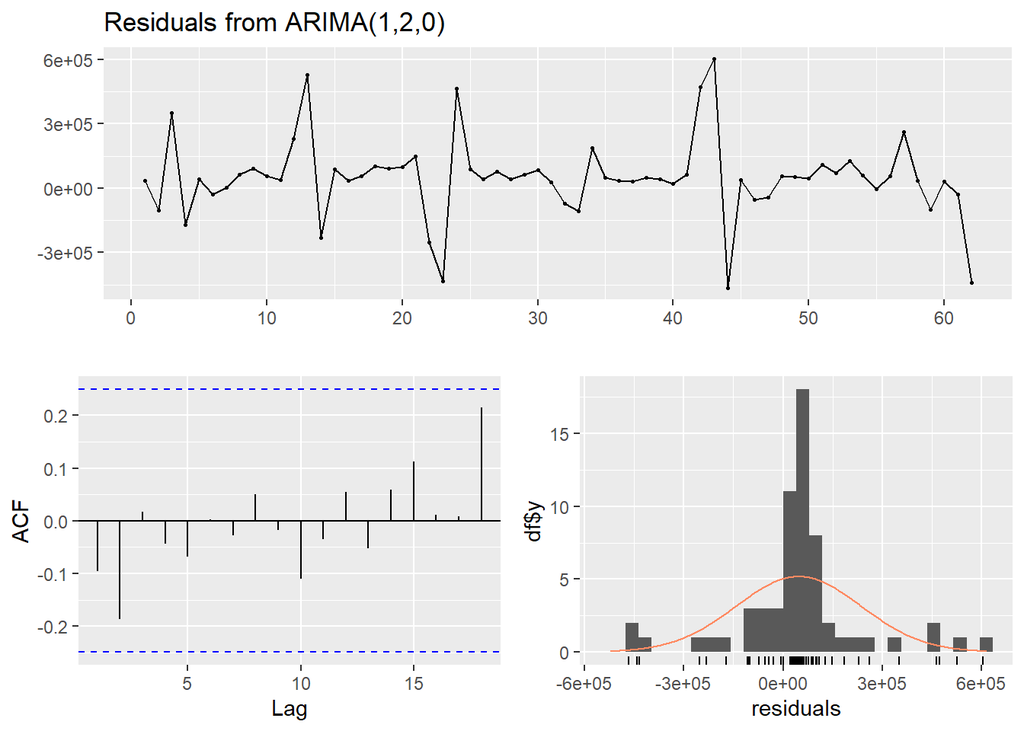

```
##
##  Ljung-Box test
##
## data:  Residuals from ARIMA(1,2,0)
## Q* = 4.5621, df = 9, p-value = 0.8707
##
## Model df: 1.   Total lags used: 10
```

```r
checkresiduals(Urbanpop_ARIMA)
```

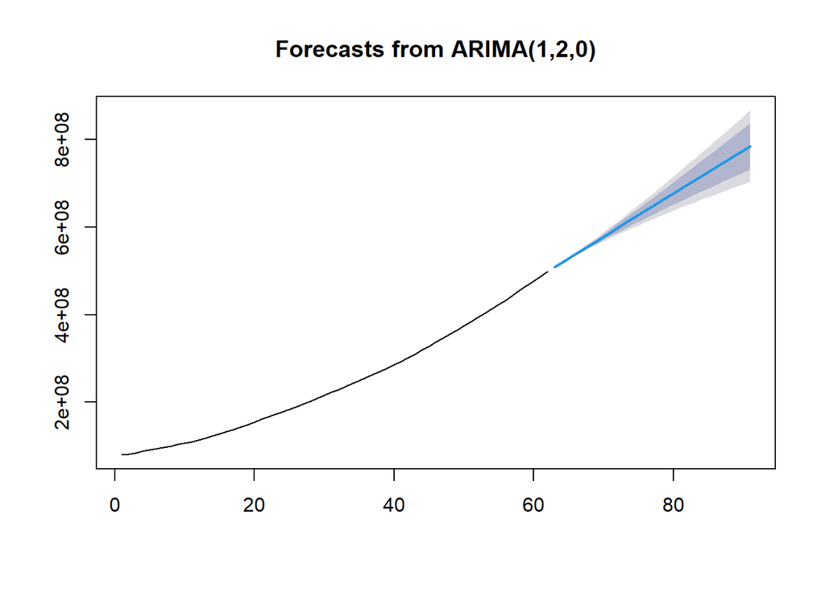

```r
Urbanpop_forecasted = forecast(Urbanpop_ARIMA,h = 2050 - electric$YEAR[nrow(electric)])
plot(Urbanpop_forecasted)
```

```r
Urbanpop_forecasted = as.data.frame(Urbanpop_forecasted)
Urbanpop_forecasted
```

```
##    Point Forecast     Lo 80     Hi 80     Lo 95     Hi 95
## 63      508395771 508141460 508650082 508006837 508784705
## 64      518458202 517751464 519164939 517377339 519539064
## 65      528429169 527076058 529782279 526359765 530498573
## 66      538345909 536172085 540519733 535021332 541670486
## 67      548230499 545080092 551380906 543412367 553048631
## 68      558096028 553829098 562362959 551570321 564621735
## 69      567950256 562440140 573460372 559523261 576377251
## 70      577797784 570928759 584666809 567292516 588303051
## 71      587641339 579306684 595975995 574894584 600388095
## 72      597482540 587582983 607382096 582342475 612622604
## 73      607322344 595764834 618879853 589646658 624998029
## 74      617161320 603858048 630464591 596815722 637506918
## 75      626999805 611867436 642132174 603856843 650142766
## 76      636837999 619797054 653878945 610776122 662899876
## 77      646676021 627650382 665701660 617578817 675773225
## 78      656513940 635430450 677597430 624269525 688758356
## 79      666351799 643139931 689563668 630852310 701851288
## 80      676189622 650781204 701598040 637330800 715048444
## 81      686027424 658356412 713698435 643708264 728346583
## 82      695865212 665867497 725862928 649987665 741742760
## 83      705702994 673316230 738089758 656171712 755234275
## 84      715540771 680704239 750377303 662262893 768818649
## 85      725378545 688033026 762724064 668263502 782493588
## 86      735216318 695303983 775128653 674175669 796256966
## 87      745054090 702518406 787589773 680001376 810106804
## 88      754891861 709677506 800106216 685742472 824041250
## 89      764729632 716782416 812676848 691400693 838058570
## 90      774567403 723834203 825300602 696977670 852157136
## 91      784405173 730833871 837976476 702474937 866335410
```

# FORECASTING THE NUMBER OF INDUSTRIES TILL 2050

```r
Industries = na.omit(electric$`Total Industries`)
adf.test(Industries)
```

```
##
##  Augmented Dickey-Fuller Test
##
## data:  Industries
## Dickey-Fuller = -1.1192, Lag order = 2, p-value = 0.9031
## alternative hypothesis: stationary
```

- We see that the original data is not stationary, hence we look at the ACF graph to determine the optimal number of lags at which the data will be stationary.

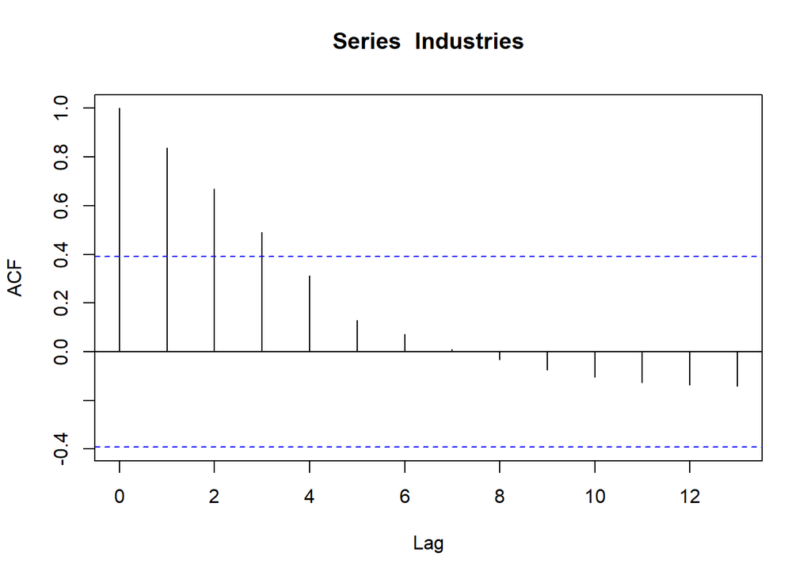

```r
acf(Industries)
```

- Here we can see that the data will be stationary at lag of order 4.
- We shall confirm this through the Augmented Dicky-Fueller test.

```r
Industries_lag = diff(Industries,lag = 4)
adf.test(Industries_lag)
```

```
##
##  Augmented Dickey-Fuller Test
##
## data:  Industries_lag
## Dickey-Fuller = -2.3249, Lag order = 2, p-value = 0.4486
## alternative hypothesis: stationary
```

- We can observe that the data is not stationary at lag 4 also. Hence, we check at lag 3 and 2 and make conclusions accordingly.

```r
Industries_lag1 = diff(Industries,lag = 3)
adf.test(Industries_lag1)
```

```
##
##  Augmented Dickey-Fuller Test
##
## data:  Industries_lag1
## Dickey-Fuller = -3.5063, Lag order = 2, p-value = 0.06302
## alternative hypothesis: stationary
```

```r
Industries_lag2 = diff(Industries,lag = 2)
adf.test(Industries_lag2)
```

```
##
##  Augmented Dickey-Fuller Test
##
## data:  Industries_lag2
## Dickey-Fuller = -2.1834, Lag order = 2, p-value = 0.5025
## alternative hypothesis: stationary
```

- Hence we see that the test is closer to significance at lag 3 than at lag 2 or 4.
- Hence we move forward with lag of order 3.

## ARIMA modelling

```r
Industries_ARIMA = auto.arima(Industries,ic = "aic")
summary(Industries_ARIMA)
```

```
## Series: Industries
## ARIMA(0,1,0) with drift
##
## Coefficients:
##          drift
##       5010.667
## s.e.  2163.102
##
## sigma^2 = 117178630:  log likelihood = -256.49
## AIC=516.99   AICc=517.56   BIC=519.34
##
## Training set error measures:
##                    ME     RMSE      MAE        MPE     MAPE      MASE
## Training set 4.206731 10382.89 5159.833 -0.5658213 3.312796 0.8894348
##                    ACF1
## Training set 0.03132882
```

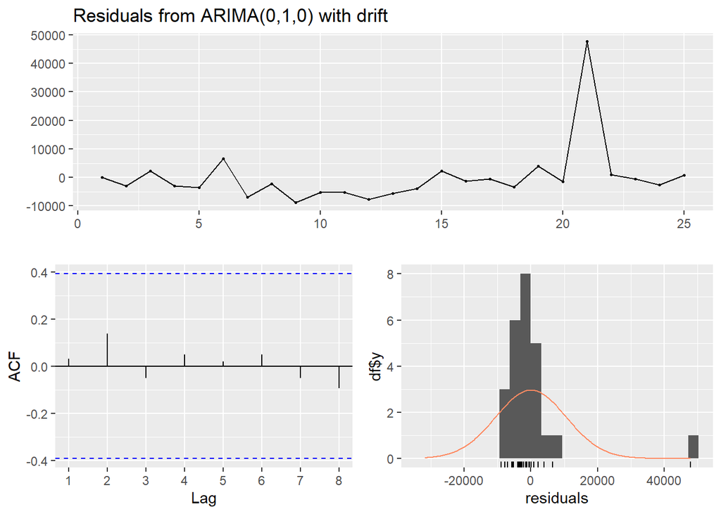

```
##
##  Ljung-Box test
##
## data:  Residuals from ARIMA(0,1,0) with drift
## Q* = 0.75964, df = 5, p-value = 0.9795
##
## Model df: 0.   Total lags used: 5
```

```r
checkresiduals(Industries_ARIMA)
```

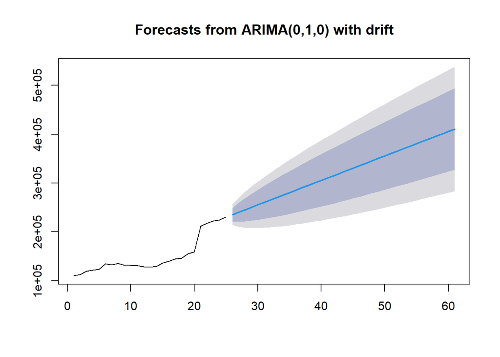

```r
Industries_forecasted = forecast(Industries_ARIMA, h = 36)
plot(Industries_forecasted)
```

```r
Industries_forecasted=as.data.frame(Industries_forecasted)
Industries_forecasted
```

```
##    Point Forecast    Lo 80    Hi 80    Lo 95    Hi 95
## 26       235445.7 221573.0 249318.3 214229.2 256662.1
## 27       240456.3 220837.4 260075.3 210451.8 270460.9
## 28       245467.0 221438.8 269495.2 208719.1 282214.9
## 29       250477.7 222732.3 278223.0 208044.8 292910.5
## 30       255488.3 224468.1 286508.6 208047.0 302929.7
## 31       260499.0 226518.0 294480.0 208529.6 312468.4
## 32       265509.7 228806.0 302213.3 209376.3 321643.1
## 33       270520.3 231282.5 309758.2 210511.2 330529.5
## 34       275531.0 233913.0 317149.0 211881.7 339180.3
## 35       280541.7 236672.4 324410.9 213449.4 347633.9
## 36       285552.3 239541.9 331562.8 215185.4 355919.3
## 37       290563.0 242506.6 338619.4 217067.1 364058.9
## 38       295573.7 245555.0 345592.3 219076.7 372070.6
## 39       300584.3 248677.5 352491.1 221199.7 379968.9
```

[output cut: 22 more lines]

# Data Cleaning

```r
electric_omitted=na.omit(electric)
head(electric_omitted)
```

```
## # A tibble: 6 × 6
##    YEAR Electric_power_consumption_(kW…¹ Urban_Population %_of_Urban_populatio…²
##   <dbl>                            <dbl>            <dbl>                  <dbl>
## 1  1990                             273.        222374415                   25.5
## 2  1991                             292.        229151406                   25.8
## 3  1992                             305.        235824041                   26.0
## 4  1993                             321.        242620668                   26.2
## 5  1994                             341.        249539704                   26.4
## 6  1995                             359.        256565748                   26.6
## # ℹ abbreviated names: ¹`Electric_power_consumption_(kWh_per_capita)`,
## #   ²`%_of_Urban_population_from_total_population`
## # ℹ 2 more variables: `Annual_%_Change_in_population` <dbl>,
## #   `Total Industries` <dbl>
```

# Finding the type of relationship

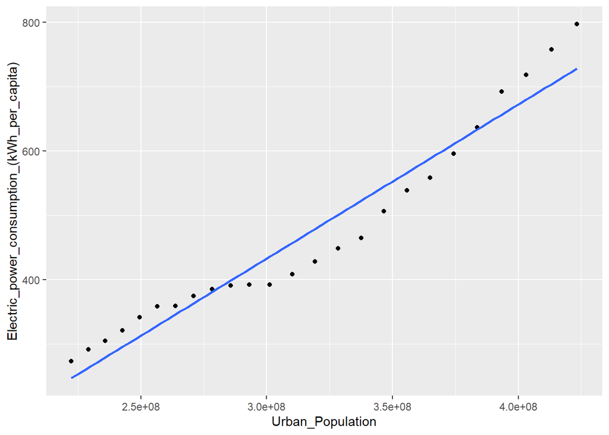

```r
library(ggplot2)
ggplot(electric_omitted,aes(Urban_Population,`Electric_power_consumption_(kWh_per_capita)`))+geom_point()+geom_smooth(method = "lm",se=F)
```

# Linear Regression Model

```r
## Level-Level Model
model.01=lm(electric_only$`Electric_power_consumption_(kWh_per_capita)`~electric_only$Urban_Population)

## Level-log Model
model.02=lm(electric_only$`Electric_power_consumption_(kWh_per_capita)`~log(electric_only$Urban_Population))
model.03=lm(log(electric_only$`Electric_power_consumption_(kWh_per_capita)`)~electric_only$Urban_Population)

## Log- Log model
model.04=lm(log(electric_only$`Electric_power_consumption_(kWh_per_capita)`)~log(electric_only$Urban_Population))

# Quadratic
model.05=lm(log(electric_only$`Electric_power_consumption_(kWh_per_capita)`)~I(electric_only$Urban_Population^2))

library(stargazer)
stargazer(model.01,model.02,model.03,model.04,model.05,type = "text")
```

```
##
## ===============================================================================================
##                                                      Dependent variable:
##                               -----------------------------------------------------------------
##                               `Electric_power_consumption      `Electric_power_consumption
##                                    (1)            (2)          (3)          (4)         (5)
## -----------------------------------------------------------------------------------------------
## Urban_Population                0.00000***                   0.000***
##                                 (0.00000)                    (0.000)
##
## Urban_Population)                             482.764***                  1.619***
##                                                (24.384)                   (0.023)
##
## Urban_Population2)                                                                    0.000***
##                                                                                       (0.000)
##
## Constant                       -190.525***   -8,965.104***   3.953***    -25.553***   4.768***
##                                  (15.020)      (469.792)     (0.050)      (0.451)     (0.054)
##
## -----------------------------------------------------------------------------------------------
## Observations                        44            44            44           44          44
## R2                                0.971          0.903        0.968        0.991       0.900
## Adjusted R2                       0.970          0.901        0.967        0.991       0.897
## Residual Std. Error (df = 42)     34.181        61.948        0.115        0.059       0.202
## F Statistic (df = 1; 42)       1,383.444***   391.982***   1,257.192*** 4,791.155*** 377.376***
## ===============================================================================================
## Note:                                                               *p<0.1; **p<0.05; ***p<0.01
```

# Auto-correlation

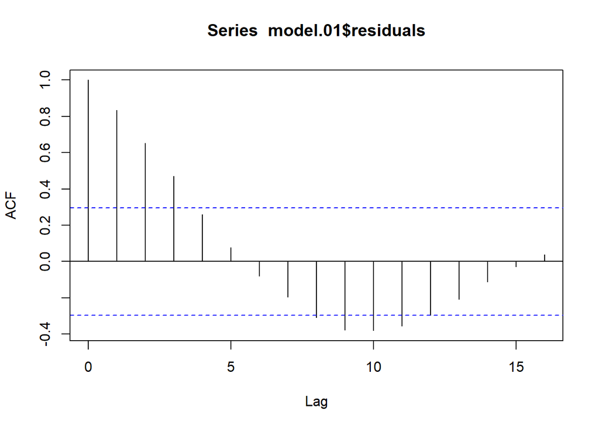

```r
acf(model.01$residuals)
```

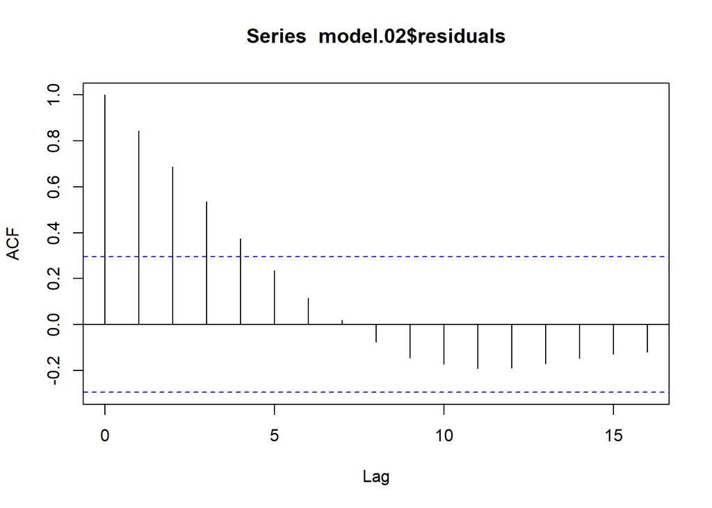

```r
acf(model.02$residuals)
```

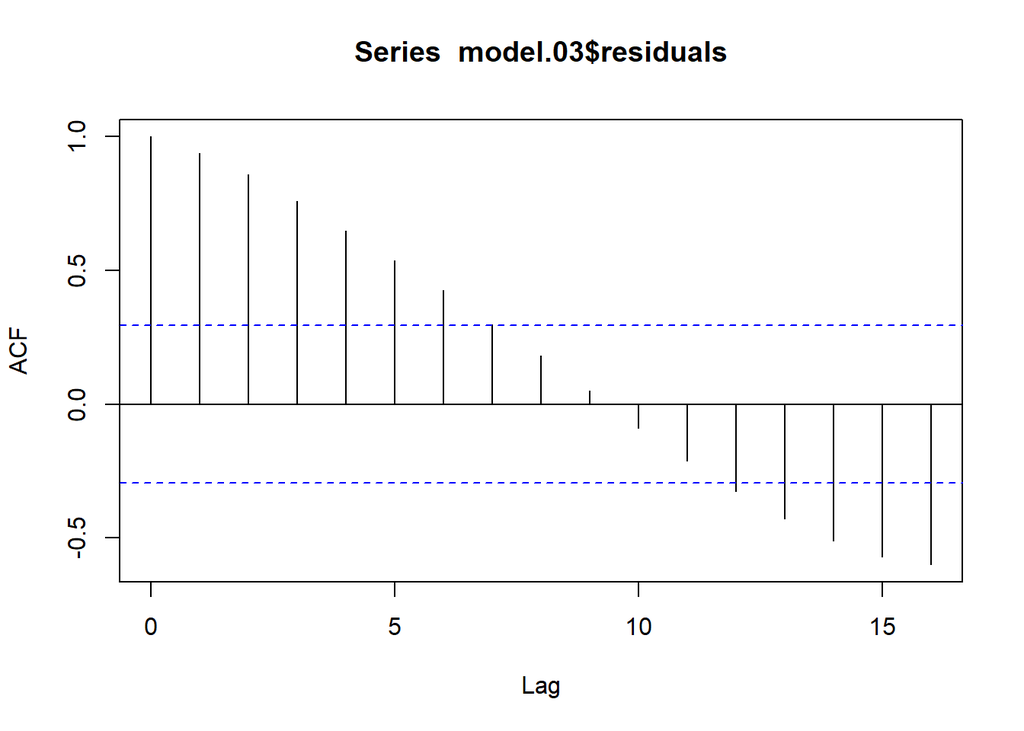

```r
acf(model.03$residuals)
```

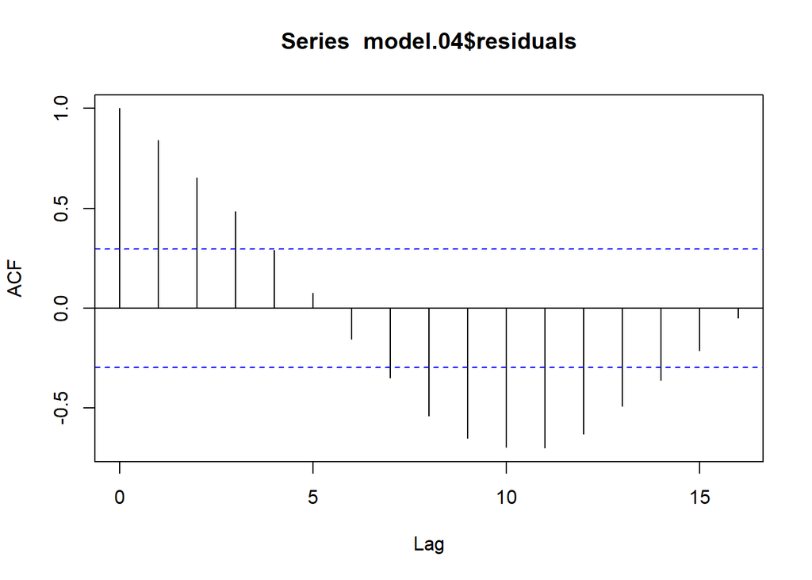

```r
acf(model.04$residuals)
```

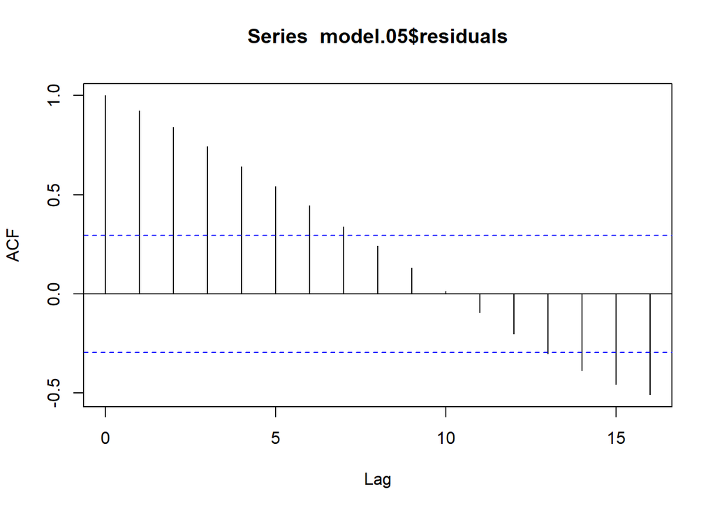

```r
acf(model.05$residuals)
```

## Auto-correlation Test

```r
library(lmtest)
bgtest(model.01,order=3,type="Chisq")
```

```
##
##  Breusch-Godfrey test for serial correlation of order up to 3
##
## data:  model.01
## LM test = 38.935, df = 3, p-value = 1.791e-08
```

```r
bgtest(model.02,order=3,type="Chisq")
```

```
##
##  Breusch-Godfrey test for serial correlation of order up to 3
##
## data:  model.02
## LM test = 39.243, df = 3, p-value = 1.542e-08
```

```r
bgtest(model.03,order=3,type="Chisq")
```

```
##
##  Breusch-Godfrey test for serial correlation of order up to 3
##
## data:  model.03
## LM test = 40.385, df = 3, p-value = 8.83e-09
```

```r
bgtest(model.04,order=3,type="Chisq")
```

```
##
##  Breusch-Godfrey test for serial correlation of order up to 3
##
## data:  model.04
## LM test = 33.032, df = 3, p-value = 3.171e-07
```

```r
bgtest(model.05,order=3,type="Chisq")
```

```
##
##  Breusch-Godfrey test for serial correlation of order up to 3
##
## data:  model.05
## LM test = 39.942, df = 3, p-value = 1.096e-08
```

# Model 4

```r
sqr_Urban_Population=electric_omitted$Urban_Population*electric_omitted$Urban_Population
model4=lm(electric_omitted$`Electric_power_consumption_(kWh_per_capita)`~sqr_Urban_Population)
summary(model4)
```

```
##
## Call:
## lm(formula = electric_omitted$`Electric_power_consumption_(kWh_per_capita)` ~
##     sqr_Urban_Population)
##
## Residuals:
##     Min      1Q  Median      3Q     Max
## -45.394 -24.982   6.146  18.531  40.082
##
## Coefficients:
##                       Estimate Std. Error t value Pr(>|t|)
## (Intercept)          7.990e+01  1.506e+01   5.305  2.2e-05 ***
## sqr_Urban_Population 3.780e-15  1.366e-16  27.667  < 2e-16 ***
## ---
## Signif. codes:  0 '***' 0.001 '**' 0.01 '*' 0.05 '.' 0.1 ' ' 1
##
## Residual standard error: 26.67 on 23 degrees of freedom
## Multiple R-squared:  0.9708, Adjusted R-squared:  0.9696
## F-statistic: 765.5 on 1 and 23 DF,  p-value: < 2.2e-16
```

- The model 4 shows a positive intercept, which is statistically significant.
- However in the residual plot it shows a pattern in the later half of the graph. There is some problem with our model. However model 4 is theoretically closest model and we shall build more upon that.

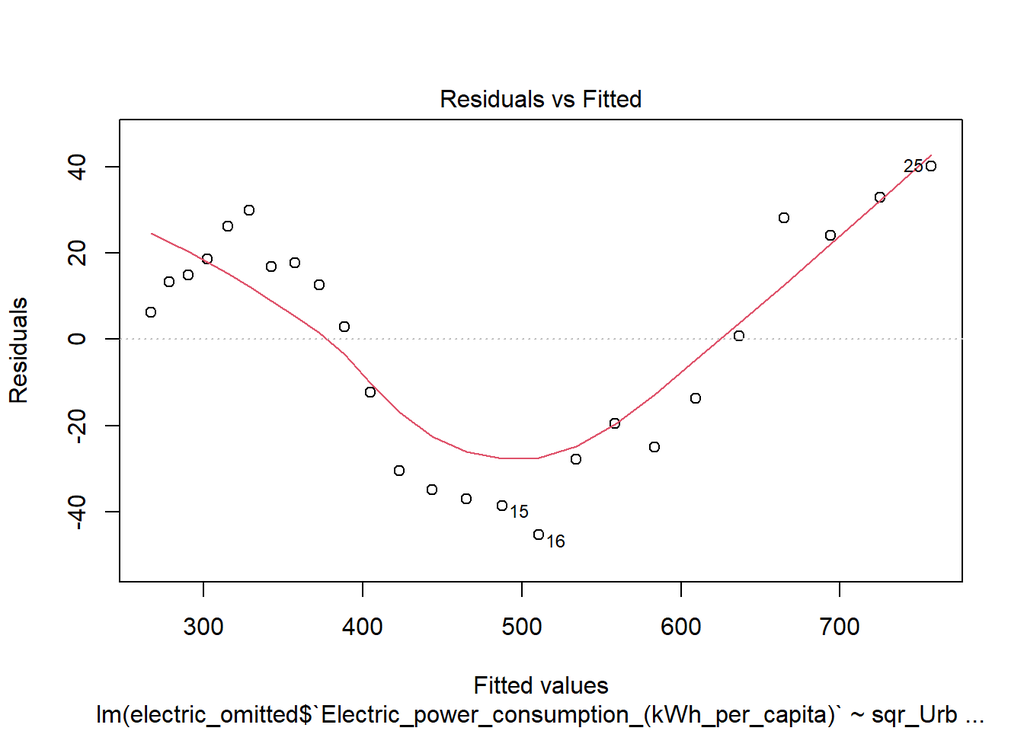

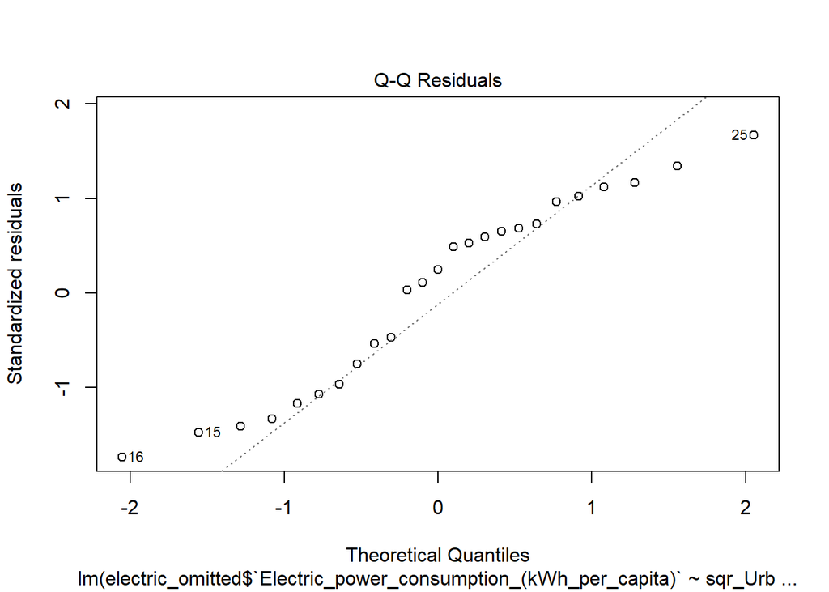

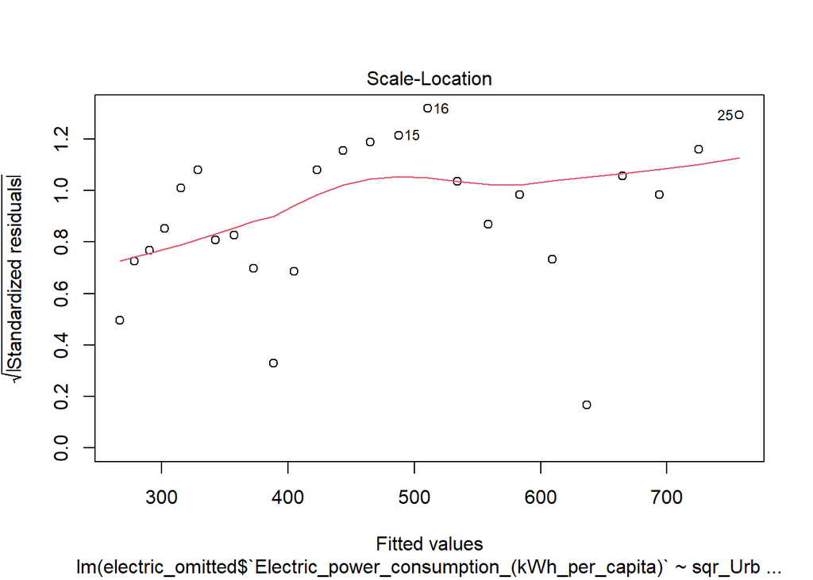

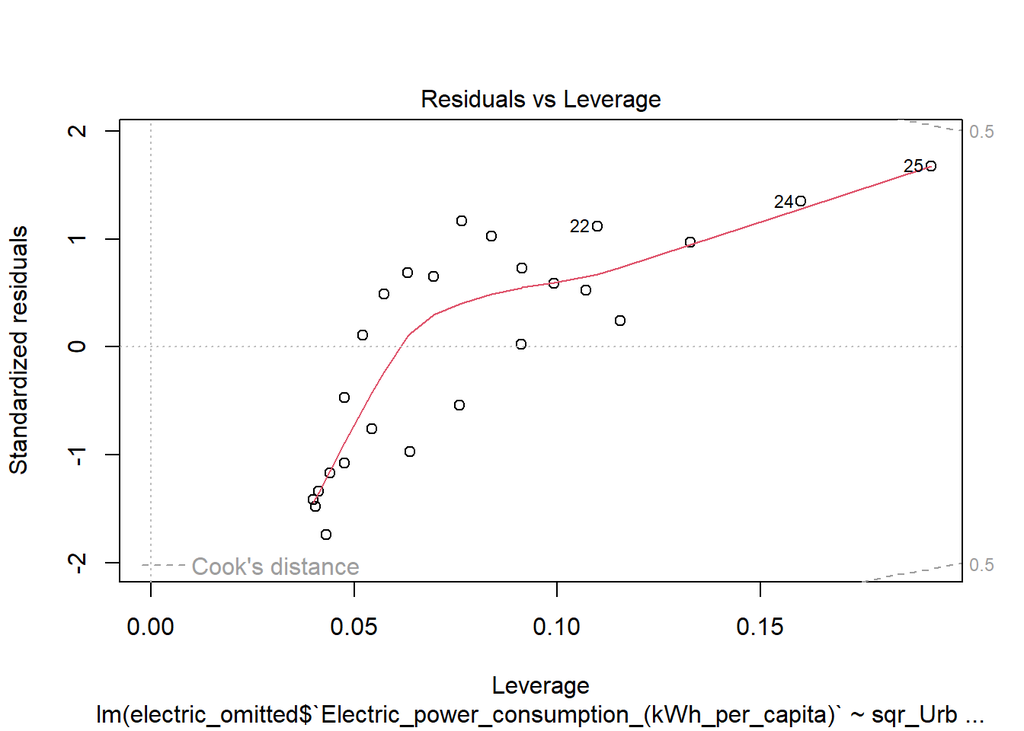

```r
plot(model4)
```